# Risk Factor Analysis

## Outcome Variable

**Outcome Variable:** pers_wasted624

## Predictor Variables

**Intervention Variable:** ever_underweight06

**Adjustment Set:**

unadjusted

## Stratifying Variables

The analysis was stratified on these variable(s):

- studyid
- country

## Data Summary

| studyid | country | ever_underweight06 | pers_wasted624 | n_cell | n |
| --- | --- | --- | --- | --- | --- |
| ki0047075b-MAL-ED | BANGLADESH | 0 | 0 | 161 | 239 |
| ki0047075b-MAL-ED | BANGLADESH | 0 | 1 | 5 | 239 |
| ki0047075b-MAL-ED | BANGLADESH | 1 | 0 | 60 | 239 |
| ki0047075b-MAL-ED | BANGLADESH | 1 | 1 | 13 | 239 |
| ki0047075b-MAL-ED | BRAZIL | 0 | 0 | 188 | 202 |
| ki0047075b-MAL-ED | BRAZIL | 0 | 1 | 2 | 202 |
| ki0047075b-MAL-ED | BRAZIL | 1 | 0 | 12 | 202 |
| ki0047075b-MAL-ED | BRAZIL | 1 | 1 | 0 | 202 |
| ki0047075b-MAL-ED | INDIA | 0 | 0 | 142 | 234 |
| ki0047075b-MAL-ED | INDIA | 0 | 1 | 1 | 234 |
| ki0047075b-MAL-ED | INDIA | 1 | 0 | 64 | 234 |
| ki0047075b-MAL-ED | INDIA | 1 | 1 | 27 | 234 |
| ki0047075b-MAL-ED | NEPAL | 0 | 0 | 197 | 234 |
| ki0047075b-MAL-ED | NEPAL | 0 | 1 | 0 | 234 |
| ki0047075b-MAL-ED | NEPAL | 1 | 0 | 35 | 234 |
| ki0047075b-MAL-ED | NEPAL | 1 | 1 | 2 | 234 |
| ki0047075b-MAL-ED | PERU | 0 | 0 | 222 | 264 |
| ki0047075b-MAL-ED | PERU | 0 | 1 | 1 | 264 |
| ki0047075b-MAL-ED | PERU | 1 | 0 | 40 | 264 |
| ki0047075b-MAL-ED | PERU | 1 | 1 | 1 | 264 |
| ki0047075b-MAL-ED | SOUTH AFRICA | 0 | 0 | 218 | 258 |
| ki0047075b-MAL-ED | SOUTH AFRICA | 0 | 1 | 0 | 258 |
| ki0047075b-MAL-ED | SOUTH AFRICA | 1 | 0 | 38 | 258 |
| ki0047075b-MAL-ED | SOUTH AFRICA | 1 | 1 | 2 | 258 |
| ki0047075b-MAL-ED | TANZANIA, UNITED REPUBLIC OF | 0 | 0 | 206 | 244 |
| ki0047075b-MAL-ED | TANZANIA, UNITED REPUBLIC OF | 0 | 1 | 0 | 244 |
| ki0047075b-MAL-ED | TANZANIA, UNITED REPUBLIC OF | 1 | 0 | 38 | 244 |
| ki0047075b-MAL-ED | TANZANIA, UNITED REPUBLIC OF | 1 | 1 | 0 | 244 |
| ki1000108-CMC-V-BCS-2002 | INDIA | 0 | 0 | 186 | 373 |
| ki1000108-CMC-V-BCS-2002 | INDIA | 0 | 1 | 4 | 373 |

[output cut: 118 more lines]

The following strata were considered:

- studyid: ki0047075b-MAL-ED, country: BANGLADESH
- studyid: ki0047075b-MAL-ED, country: BRAZIL
- studyid: ki0047075b-MAL-ED, country: INDIA
- studyid: ki0047075b-MAL-ED, country: NEPAL
- studyid: ki0047075b-MAL-ED, country: PERU
- studyid: ki0047075b-MAL-ED, country: SOUTH AFRICA
- studyid: ki0047075b-MAL-ED, country: TANZANIA, UNITED REPUBLIC OF
- studyid: ki1000108-CMC-V-BCS-2002, country: INDIA
- studyid: ki1000108-IRC, country: INDIA
- studyid: ki1000109-EE, country: PAKISTAN
- studyid: ki1000109-ResPak, country: PAKISTAN
- studyid: ki1000304-VITAMIN-A, country: INDIA
- studyid: ki1000304b-SAS-CompFeed, country: INDIA
- studyid: ki1000304b-SAS-FoodSuppl, country: INDIA
- studyid: ki1017093-NIH-Birth, country: BANGLADESH
- studyid: ki1017093b-PROVIDE, country: BANGLADESH
- studyid: ki1017093c-NIH-Crypto, country: BANGLADESH
- studyid: ki1066203-TanzaniaChild2, country: TANZANIA, UNITED REPUBLIC OF
- studyid: ki1101329-Keneba, country: GAMBIA
- studyid: ki1112895-Burkina Faso Zn, country: BURKINA FASO
- studyid: ki1112895-Guatemala BSC, country: GUATEMALA
- studyid: ki1113344-GMS-Nepal, country: NEPAL
- studyid: ki1114097-CMIN, country: BANGLADESH
- studyid: ki1114097-CMIN, country: BRAZIL
- studyid: ki1114097-CMIN, country: GUINEA-BISSAU
- studyid: ki1114097-CMIN, country: PERU
- studyid: ki1114097-CONTENT, country: PERU
- studyid: ki1119695-PROBIT, country: BELARUS
- studyid: ki1126311-ZVITAMBO, country: ZIMBABWE
- studyid: ki1135781-COHORTS, country: GUATEMALA
- studyid: ki1135781-COHORTS, country: INDIA
- studyid: ki1135781-COHORTS, country: PHILIPPINES
- studyid: ki1148112-iLiNS-DOSE, country: MALAWI
- studyid: ki1148112-iLiNS-DYAD-M, country: MALAWI
- studyid: ki1148112-LCNI-5, country: MALAWI
- studyid: kiGH5241-JiVitA-3, country: BANGLADESH
- studyid: kiGH5241-JiVitA-4, country: BANGLADESH

### Dropped Strata

Some strata were dropped due to rare outcomes:

- studyid: ki0047075b-MAL-ED, country: BRAZIL
- studyid: ki0047075b-MAL-ED, country: INDIA
- studyid: ki0047075b-MAL-ED, country: NEPAL
- studyid: ki0047075b-MAL-ED, country: PERU
- studyid: ki0047075b-MAL-ED, country: SOUTH AFRICA
- studyid: ki0047075b-MAL-ED, country: TANZANIA, UNITED REPUBLIC OF
- studyid: ki1000108-CMC-V-BCS-2002, country: INDIA
- studyid: ki1000109-EE, country: PAKISTAN
- studyid: ki1112895-Burkina Faso Zn, country: BURKINA FASO
- studyid: ki1112895-Guatemala BSC, country: GUATEMALA
- studyid: ki1114097-CMIN, country: BANGLADESH
- studyid: ki1114097-CMIN, country: BRAZIL
- studyid: ki1114097-CMIN, country: PERU
- studyid: ki1114097-CONTENT, country: PERU
- studyid: ki1148112-LCNI-5, country: MALAWI

## Methods Detail

We’re interested in the causal parameters $E[Y_a]$ for all values of $a \in \mathcal{A}$. These parameters represent the mean outcome if, possibly contrary to fact, we intervened to set all units to have $A=a$. Under the randomization and positivity assumptions, these are identified by the statistical parameters $\psi_a=E_W[E_{Y|A,W}(Y|A=a,W)]$. In addition, we’re interested in the mean of $Y$, $E[Y]$ under no intervention (the observed mean). We will estimate these parameters by using SuperLearner to fit the relevant likelihood factors – $E_{Y|A,W}(Y|A=a,W)$ and $p(A=a|W)$, and then updating our likelihood fit using a joint TMLE.

For unadjusted analyses ($W=\{\}$), initial likelihoods were estimated using Lrnr_glm to estimate the simple $E(Y|A)$ and Lrnr_mean to estimate $p(A)$. For adjusted analyses, a small library containing Lrnr_glmnet, Lrnr_xgboost, and Lrnr_mean was used.

Having estimated these parameters, we will then use the delta method to estimate relative risks and attributable risks relative to a prespecified baseline level of $A$.

# Results Detail

## Results Plots

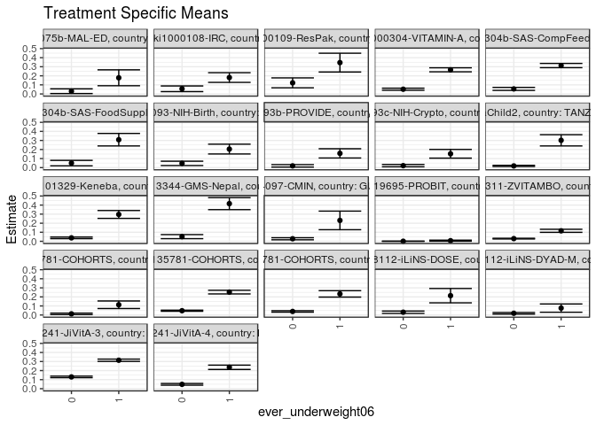

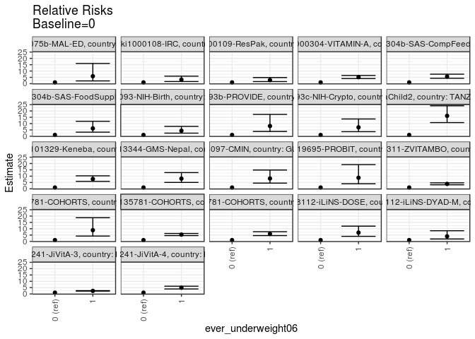

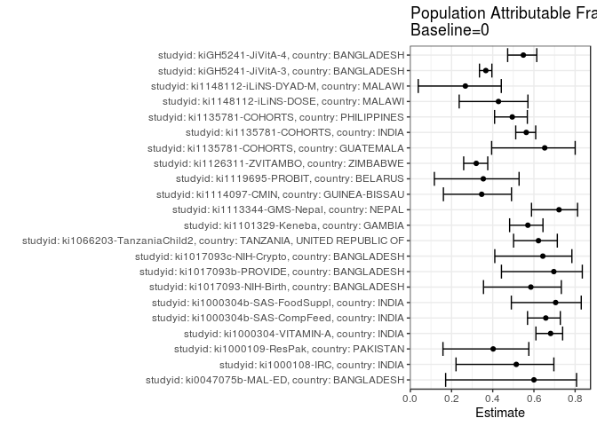

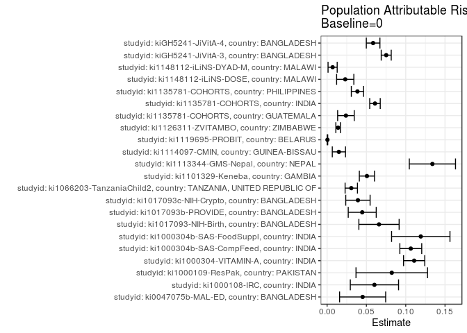

## Results Table

### Parameter: TSM

| studyid | country | intervention_level | baseline_level | estimate | ci_lower | ci_upper |
| --- | --- | --- | --- | --- | --- | --- |
| ki0047075b-MAL-ED | BANGLADESH | 0 | NA | 0.0301205 | 0.0040653 | 0.0561757 |
| ki0047075b-MAL-ED | BANGLADESH | 1 | NA | 0.1780822 | 0.0901351 | 0.2660293 |
| ki1000108-IRC | INDIA | 0 | NA | 0.0568720 | 0.0255845 | 0.0881596 |
| ki1000108-IRC | INDIA | 1 | NA | 0.1809045 | 0.1273565 | 0.2344526 |
| ki1000109-ResPak | PAKISTAN | 0 | NA | 0.1223022 | 0.0677113 | 0.1768930 |
| ki1000109-ResPak | PAKISTAN | 1 | NA | 0.3456790 | 0.2418720 | 0.4494860 |
| ki1000304-VITAMIN-A | INDIA | 0 | NA | 0.0518570 | 0.0403504 | 0.0633637 |
| ki1000304-VITAMIN-A | INDIA | 1 | NA | 0.2662295 | 0.2440427 | 0.2884163 |
| ki1000304b-SAS-CompFeed | INDIA | 0 | NA | 0.0554156 | 0.0388909 | 0.0719403 |
| ki1000304b-SAS-CompFeed | INDIA | 1 | NA | 0.3130590 | 0.2896449 | 0.3364731 |
| ki1000304b-SAS-FoodSuppl | INDIA | 0 | NA | 0.0497512 | 0.0196521 | 0.0798504 |
| ki1000304b-SAS-FoodSuppl | INDIA | 1 | NA | 0.3081395 | 0.2390440 | 0.3772350 |
| ki1017093-NIH-Birth | BANGLADESH | 0 | NA | 0.0468227 | 0.0228537 | 0.0707918 |
| ki1017093-NIH-Birth | BANGLADESH | 1 | NA | 0.2046512 | 0.1506706 | 0.2586318 |
| ki1017093b-PROVIDE | BANGLADESH | 0 | NA | 0.0194647 | 0.0060975 | 0.0328319 |
| ki1017093b-PROVIDE | BANGLADESH | 1 | NA | 0.1573604 | 0.1064694 | 0.2082514 |
| ki1017093c-NIH-Crypto | BANGLADESH | 0 | NA | 0.0217391 | 0.0090240 | 0.0344543 |
| ki1017093c-NIH-Crypto | BANGLADESH | 1 | NA | 0.1527778 | 0.1047657 | 0.2007899 |
| ki1066203-TanzaniaChild2 | TANZANIA, UNITED REPUBLIC OF | 0 | NA | 0.0186916 | 0.0122745 | 0.0251086 |
| ki1066203-TanzaniaChild2 | TANZANIA, UNITED REPUBLIC OF | 1 | NA | 0.3014354 | 0.2392070 | 0.3636638 |
| ki1101329-Keneba | GAMBIA | 0 | NA | 0.0381332 | 0.0291760 | 0.0470903 |
| ki1101329-Keneba | GAMBIA | 1 | NA | 0.2967290 | 0.2534410 | 0.3400169 |
| ki1113344-GMS-Nepal | NEPAL | 0 | NA | 0.0516304 | 0.0290028 | 0.0742581 |
| ki1113344-GMS-Nepal | NEPAL | 1 | NA | 0.4158879 | 0.3497956 | 0.4819802 |
| ki1114097-CMIN | GUINEA-BISSAU | 0 | NA | 0.0282903 | 0.0168868 | 0.0396938 |
| ki1114097-CMIN | GUINEA-BISSAU | 1 | NA | 0.2307692 | 0.1282852 | 0.3332532 |
| ki1119695-PROBIT | BELARUS | 0 | NA | 0.0007852 | 0.0000497 | 0.0015207 |
| ki1119695-PROBIT | BELARUS | 1 | NA | 0.0068552 | 0.0013591 | 0.0123513 |
| ki1126311-ZVITAMBO | ZIMBABWE | 0 | NA | 0.0298383 | 0.0259004 | 0.0337761 |
| ki1126311-ZVITAMBO | ZIMBABWE | 1 | NA | 0.1157970 | 0.0990287 | 0.1325653 |
| ki1135781-COHORTS | GUATEMALA | 0 | NA | 0.0127660 | 0.0044746 | 0.0210573 |
| ki1135781-COHORTS | GUATEMALA | 1 | NA | 0.1131222 | 0.0713399 | 0.1549045 |
| ki1135781-COHORTS | INDIA | 0 | NA | 0.0473052 | 0.0409216 | 0.0536889 |
| ki1135781-COHORTS | INDIA | 1 | NA | 0.2530795 | 0.2329140 | 0.2732450 |
| ki1135781-COHORTS | PHILIPPINES | 0 | NA | 0.0394022 | 0.0312859 | 0.0475185 |
| ki1135781-COHORTS | PHILIPPINES | 1 | NA | 0.2331512 | 0.1977747 | 0.2685276 |
| ki1148112-iLiNS-DOSE | MALAWI | 0 | NA | 0.0308555 | 0.0181548 | 0.0435563 |
| ki1148112-iLiNS-DOSE | MALAWI | 1 | NA | 0.2135922 | 0.1343946 | 0.2927899 |
| ki1148112-iLiNS-DYAD-M | MALAWI | 0 | NA | 0.0192513 | 0.0104397 | 0.0280629 |
| ki1148112-iLiNS-DYAD-M | MALAWI | 1 | NA | 0.0763359 | 0.0308436 | 0.1218282 |
| kiGH5241-JiVitA-3 | BANGLADESH | 0 | NA | 0.1300059 | 0.1216259 | 0.1383860 |
| kiGH5241-JiVitA-3 | BANGLADESH | 1 | NA | 0.3141136 | 0.3012366 | 0.3269906 |
| kiGH5241-JiVitA-4 | BANGLADESH | 0 | NA | 0.0481513 | 0.0386653 | 0.0576373 |
| kiGH5241-JiVitA-4 | BANGLADESH | 1 | NA | 0.2364908 | 0.2124403 | 0.2605412 |

### Parameter: E(Y)

| studyid | country | intervention_level | baseline_level | estimate | ci_lower | ci_upper |
| --- | --- | --- | --- | --- | --- | --- |
| ki0047075b-MAL-ED | BANGLADESH | NA | NA | 0.0753138 | 0.0417869 | 0.1088408 |
| ki1000108-IRC | INDIA | NA | NA | 0.1170732 | 0.0859146 | 0.1482317 |
| ki1000109-ResPak | PAKISTAN | NA | NA | 0.2045455 | 0.1511224 | 0.2579685 |
| ki1000304-VITAMIN-A | INDIA | NA | NA | 0.1626016 | 0.1492881 | 0.1759151 |
| ki1000304b-SAS-CompFeed | INDIA | NA | NA | 0.1618625 | 0.1426768 | 0.1810483 |
| ki1000304b-SAS-FoodSuppl | INDIA | NA | NA | 0.1689008 | 0.1308276 | 0.2069740 |
| ki1017093-NIH-Birth | BANGLADESH | NA | NA | 0.1128405 | 0.0854611 | 0.1402198 |
| ki1017093b-PROVIDE | BANGLADESH | NA | NA | 0.0641447 | 0.0446535 | 0.0836359 |
| ki1017093c-NIH-Crypto | BANGLADESH | NA | NA | 0.0609418 | 0.0434802 | 0.0784034 |
| ki1066203-TanzaniaChild2 | TANZANIA, UNITED REPUBLIC OF | NA | NA | 0.0494534 | 0.0397554 | 0.0591514 |
| ki1101329-Keneba | GAMBIA | NA | NA | 0.0887872 | 0.0768581 | 0.1007163 |
| ki1113344-GMS-Nepal | NEPAL | NA | NA | 0.1855670 | 0.1539560 | 0.2171780 |
| ki1114097-CMIN | GUINEA-BISSAU | NA | NA | 0.0432802 | 0.0298127 | 0.0567476 |
| ki1119695-PROBIT | BELARUS | NA | NA | 0.0012159 | 0.0002433 | 0.0021885 |
| ki1126311-ZVITAMBO | ZIMBABWE | NA | NA | 0.0438689 | 0.0395328 | 0.0482049 |
| ki1135781-COHORTS | GUATEMALA | NA | NA | 0.0367171 | 0.0245975 | 0.0488367 |
| ki1135781-COHORTS | INDIA | NA | NA | 0.1082022 | 0.1003643 | 0.1160400 |
| ki1135781-COHORTS | PHILIPPINES | NA | NA | 0.0779833 | 0.0679723 | 0.0879943 |
| ki1148112-iLiNS-DOSE | MALAWI | NA | NA | 0.0539216 | 0.0384151 | 0.0694281 |
| ki1148112-iLiNS-DYAD-M | MALAWI | NA | NA | 0.0262664 | 0.0166615 | 0.0358713 |
| kiGH5241-JiVitA-3 | BANGLADESH | NA | NA | 0.2052021 | 0.1976666 | 0.2127376 |
| kiGH5241-JiVitA-4 | BANGLADESH | NA | NA | 0.1066772 | 0.0962568 | 0.1170977 |

### Parameter: RR

| studyid | country | intervention_level | baseline_level | estimate | ci_lower | ci_upper |
| --- | --- | --- | --- | --- | --- | --- |
| ki0047075b-MAL-ED | BANGLADESH | 0 | 0 | 1.000000 | 1.000000 | 1.000000 |
| ki0047075b-MAL-ED | BANGLADESH | 1 | 0 | 5.912329 | 2.183566 | 16.008504 |
| ki1000108-IRC | INDIA | 0 | 0 | 1.000000 | 1.000000 | 1.000000 |
| ki1000108-IRC | INDIA | 1 | 0 | 3.180905 | 1.703098 | 5.941028 |
| ki1000109-ResPak | PAKISTAN | 0 | 0 | 1.000000 | 1.000000 | 1.000000 |
| ki1000109-ResPak | PAKISTAN | 1 | 0 | 2.826434 | 1.650439 | 4.840368 |
| ki1000304-VITAMIN-A | INDIA | 0 | 0 | 1.000000 | 1.000000 | 1.000000 |
| ki1000304-VITAMIN-A | INDIA | 1 | 0 | 5.133912 | 4.050506 | 6.507102 |
| ki1000304b-SAS-CompFeed | INDIA | 0 | 0 | 1.000000 | 1.000000 | 1.000000 |
| ki1000304b-SAS-CompFeed | INDIA | 1 | 0 | 5.649293 | 4.255149 | 7.500208 |
| ki1000304b-SAS-FoodSuppl | INDIA | 0 | 0 | 1.000000 | 1.000000 | 1.000000 |
| ki1000304b-SAS-FoodSuppl | INDIA | 1 | 0 | 6.193605 | 3.248869 | 11.807415 |
| ki1017093-NIH-Birth | BANGLADESH | 0 | 0 | 1.000000 | 1.000000 | 1.000000 |
| ki1017093-NIH-Birth | BANGLADESH | 1 | 0 | 4.370764 | 2.457312 | 7.774177 |
| ki1017093b-PROVIDE | BANGLADESH | 0 | 0 | 1.000000 | 1.000000 | 1.000000 |
| ki1017093b-PROVIDE | BANGLADESH | 1 | 0 | 8.084391 | 3.784280 | 17.270755 |
| ki1017093c-NIH-Crypto | BANGLADESH | 0 | 0 | 1.000000 | 1.000000 | 1.000000 |
| ki1017093c-NIH-Crypto | BANGLADESH | 1 | 0 | 7.027778 | 3.617899 | 13.651476 |
| ki1066203-TanzaniaChild2 | TANZANIA, UNITED REPUBLIC OF | 0 | 0 | 1.000000 | 1.000000 | 1.000000 |
| ki1066203-TanzaniaChild2 | TANZANIA, UNITED REPUBLIC OF | 1 | 0 | 16.126794 | 10.803626 | 24.072797 |
| ki1101329-Keneba | GAMBIA | 0 | 0 | 1.000000 | 1.000000 | 1.000000 |
| ki1101329-Keneba | GAMBIA | 1 | 0 | 7.781385 | 5.901622 | 10.259883 |
| ki1113344-GMS-Nepal | NEPAL | 0 | 0 | 1.000000 | 1.000000 | 1.000000 |
| ki1113344-GMS-Nepal | NEPAL | 1 | 0 | 8.055091 | 5.053693 | 12.839024 |
| ki1114097-CMIN | GUINEA-BISSAU | 0 | 0 | 1.000000 | 1.000000 | 1.000000 |
| ki1114097-CMIN | GUINEA-BISSAU | 1 | 0 | 8.157191 | 4.477871 | 14.859685 |
| ki1119695-PROBIT | BELARUS | 0 | 0 | 1.000000 | 1.000000 | 1.000000 |
| ki1119695-PROBIT | BELARUS | 1 | 0 | 8.730077 | 3.986648 | 19.117378 |
| ki1126311-ZVITAMBO | ZIMBABWE | 0 | 0 | 1.000000 | 1.000000 | 1.000000 |
| ki1126311-ZVITAMBO | ZIMBABWE | 1 | 0 | 3.880823 | 3.190324 | 4.720769 |
| ki1135781-COHORTS | GUATEMALA | 0 | 0 | 1.000000 | 1.000000 | 1.000000 |
| ki1135781-COHORTS | GUATEMALA | 1 | 0 | 8.861237 | 4.197626 | 18.706174 |
| ki1135781-COHORTS | INDIA | 0 | 0 | 1.000000 | 1.000000 | 1.000000 |
| ki1135781-COHORTS | INDIA | 1 | 0 | 5.349924 | 4.573905 | 6.257606 |
| ki1135781-COHORTS | PHILIPPINES | 0 | 0 | 1.000000 | 1.000000 | 1.000000 |
| ki1135781-COHORTS | PHILIPPINES | 1 | 0 | 5.917216 | 4.581510 | 7.642339 |
| ki1148112-iLiNS-DOSE | MALAWI | 0 | 0 | 1.000000 | 1.000000 | 1.000000 |
| ki1148112-iLiNS-DOSE | MALAWI | 1 | 0 | 6.922330 | 3.977893 | 12.046240 |
| ki1148112-iLiNS-DYAD-M | MALAWI | 0 | 0 | 1.000000 | 1.000000 | 1.000000 |
| ki1148112-iLiNS-DYAD-M | MALAWI | 1 | 0 | 3.965225 | 1.870350 | 8.406451 |
| kiGH5241-JiVitA-3 | BANGLADESH | 0 | 0 | 1.000000 | 1.000000 | 1.000000 |
| kiGH5241-JiVitA-3 | BANGLADESH | 1 | 0 | 2.416148 | 2.240060 | 2.606078 |
| kiGH5241-JiVitA-4 | BANGLADESH | 0 | 0 | 1.000000 | 1.000000 | 1.000000 |
| kiGH5241-JiVitA-4 | BANGLADESH | 1 | 0 | 4.911407 | 3.934388 | 6.131047 |

### Parameter: PAR

| studyid | country | intervention_level | baseline_level | estimate | ci_lower | ci_upper |
| --- | --- | --- | --- | --- | --- | --- |
| ki0047075b-MAL-ED | BANGLADESH | 0 | NA | 0.0451933 | 0.0158694 | 0.0745173 |
| ki1000108-IRC | INDIA | 0 | NA | 0.0602011 | 0.0295058 | 0.0908965 |
| ki1000109-ResPak | PAKISTAN | 0 | NA | 0.0822433 | 0.0367642 | 0.1277223 |
| ki1000304-VITAMIN-A | INDIA | 0 | NA | 0.1107446 | 0.0972670 | 0.1242221 |
| ki1000304b-SAS-CompFeed | INDIA | 0 | NA | 0.1064469 | 0.0925294 | 0.1203644 |
| ki1000304b-SAS-FoodSuppl | INDIA | 0 | NA | 0.1191496 | 0.0820129 | 0.1562862 |
| ki1017093-NIH-Birth | BANGLADESH | 0 | NA | 0.0660177 | 0.0404103 | 0.0916251 |
| ki1017093b-PROVIDE | BANGLADESH | 0 | NA | 0.0446800 | 0.0268751 | 0.0624849 |
| ki1017093c-NIH-Crypto | BANGLADESH | 0 | NA | 0.0392027 | 0.0237118 | 0.0546936 |
| ki1066203-TanzaniaChild2 | TANZANIA, UNITED REPUBLIC OF | 0 | NA | 0.0307618 | 0.0228984 | 0.0386252 |
| ki1101329-Keneba | GAMBIA | 0 | NA | 0.0506540 | 0.0409843 | 0.0603237 |
| ki1113344-GMS-Nepal | NEPAL | 0 | NA | 0.1339366 | 0.1045465 | 0.1633266 |
| ki1114097-CMIN | GUINEA-BISSAU | 0 | NA | 0.0149899 | 0.0065883 | 0.0233915 |
| ki1119695-PROBIT | BELARUS | 0 | NA | 0.0004306 | 0.0000672 | 0.0007940 |
| ki1126311-ZVITAMBO | ZIMBABWE | 0 | NA | 0.0140306 | 0.0111398 | 0.0169214 |
| ki1135781-COHORTS | GUATEMALA | 0 | NA | 0.0239511 | 0.0134177 | 0.0344845 |
| ki1135781-COHORTS | INDIA | 0 | NA | 0.0608969 | 0.0542036 | 0.0675902 |
| ki1135781-COHORTS | PHILIPPINES | 0 | NA | 0.0385811 | 0.0307977 | 0.0463645 |
| ki1148112-iLiNS-DOSE | MALAWI | 0 | NA | 0.0230660 | 0.0121177 | 0.0340143 |
| ki1148112-iLiNS-DYAD-M | MALAWI | 0 | NA | 0.0070151 | 0.0012105 | 0.0128197 |
| kiGH5241-JiVitA-3 | BANGLADESH | 0 | NA | 0.0751962 | 0.0688272 | 0.0815651 |
| kiGH5241-JiVitA-4 | BANGLADESH | 0 | NA | 0.0585259 | 0.0498579 | 0.0671939 |

### Parameter: PAF

| studyid | country | intervention_level | baseline_level | estimate | ci_lower | ci_upper |
| --- | --- | --- | --- | --- | --- | --- |
| ki0047075b-MAL-ED | BANGLADESH | 0 | NA | 0.6000669 | 0.1713348 | 0.8069830 |
| ki1000108-IRC | INDIA | 0 | NA | 0.5142180 | 0.2217101 | 0.6967915 |
| ki1000109-ResPak | PAKISTAN | 0 | NA | 0.4020783 | 0.1583273 | 0.5752383 |
| ki1000304-VITAMIN-A | INDIA | 0 | NA | 0.6810792 | 0.6097328 | 0.7393825 |
| ki1000304b-SAS-CompFeed | INDIA | 0 | NA | 0.6576378 | 0.5689304 | 0.7280905 |
| ki1000304b-SAS-FoodSuppl | INDIA | 0 | NA | 0.7054410 | 0.4903219 | 0.8297651 |
| ki1017093-NIH-Birth | BANGLADESH | 0 | NA | 0.5850536 | 0.3551119 | 0.7330072 |
| ki1017093b-PROVIDE | BANGLADESH | 0 | NA | 0.6965500 | 0.4422711 | 0.8348985 |
| ki1017093c-NIH-Crypto | BANGLADESH | 0 | NA | 0.6432806 | 0.4100184 | 0.7843175 |
| ki1066203-TanzaniaChild2 | TANZANIA, UNITED REPUBLIC OF | 0 | NA | 0.6220364 | 0.5012337 | 0.7135803 |
| ki1101329-Keneba | GAMBIA | 0 | NA | 0.5705103 | 0.4819926 | 0.6439020 |
| ki1113344-GMS-Nepal | NEPAL | 0 | NA | 0.7217693 | 0.5883166 | 0.8119616 |
| ki1114097-CMIN | GUINEA-BISSAU | 0 | NA | 0.3463456 | 0.1604901 | 0.4910553 |
| ki1119695-PROBIT | BELARUS | 0 | NA | 0.3541814 | 0.1165915 | 0.5278722 |
| ki1126311-ZVITAMBO | ZIMBABWE | 0 | NA | 0.3198305 | 0.2588987 | 0.3757527 |
| ki1135781-COHORTS | GUATEMALA | 0 | NA | 0.6523154 | 0.3946600 | 0.8003030 |
| ki1135781-COHORTS | INDIA | 0 | NA | 0.5628068 | 0.5116457 | 0.6086081 |
| ki1135781-COHORTS | PHILIPPINES | 0 | NA | 0.4947358 | 0.4089896 | 0.5680416 |
| ki1148112-iLiNS-DOSE | MALAWI | 0 | NA | 0.4277700 | 0.2371081 | 0.5707817 |
| ki1148112-iLiNS-DYAD-M | MALAWI | 0 | NA | 0.2670741 | 0.0381922 | 0.4414888 |
| kiGH5241-JiVitA-3 | BANGLADESH | 0 | NA | 0.3664493 | 0.3355815 | 0.3958830 |
| kiGH5241-JiVitA-4 | BANGLADESH | 0 | NA | 0.5486258 | 0.4724458 | 0.6138053 |